# Tax Loophole Using Film Production Companies

Gabriel Reyes

2025-1-20

# Background

# Section of graphs:

### Constructed variable of movie suspicion:

We created a constructed variable to be able to graph how likely a producer/production company acted in a manner that would lead us to believe it could be for tax purposes. We used the parameters of career length and quantity of credited films.

Here is the key for level of suspicion:

```
0: A production company/producer worked on more than one film and year.

1: A production company/producer only made one movie ever.

2: A production company/producer made more than one movie been only had a career length of 2 years.

3: A production company/producer made multiple movies in only just one year.

4: The data point has a blank for production company/producer.
```

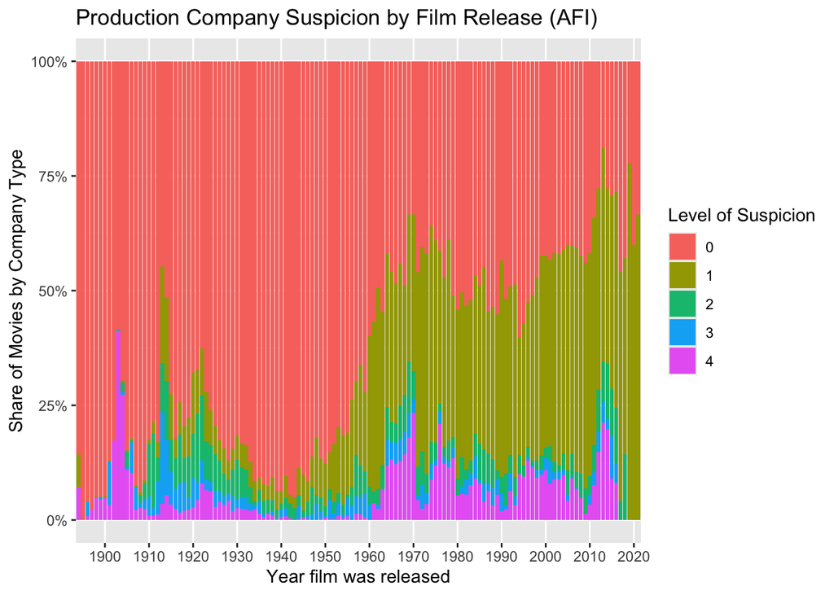

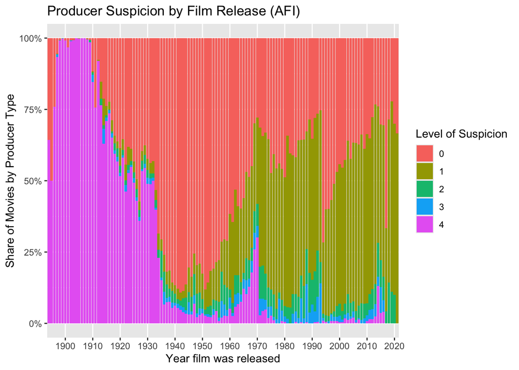

The producer data results is much more noisy, from 1900s to around 1935 there are a lot films in the data that are missing producer credits. Starting at 1940s there is a trend of producers only ever produced one film. This goes all the way to roughly 1990, then there is a recent and goes back up to 75% of producers only producing one film. There is some other levels of suspicion in producers from 1970 to 1990, but it is a small share of producers that either only produced two films in two years or produced multiple films in on year. Overall this a less productive graph as there is more variance in producers than production films. In the data there is roughly 80,000 producers and 60,000 production companies in the data.

### Count of producers / production companies per film

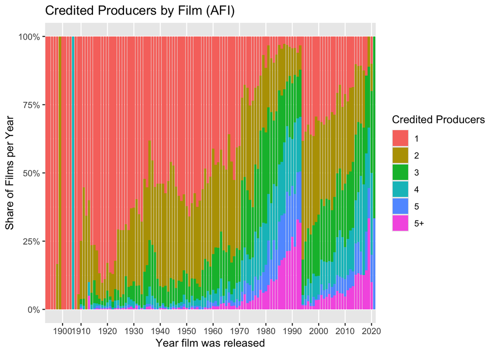

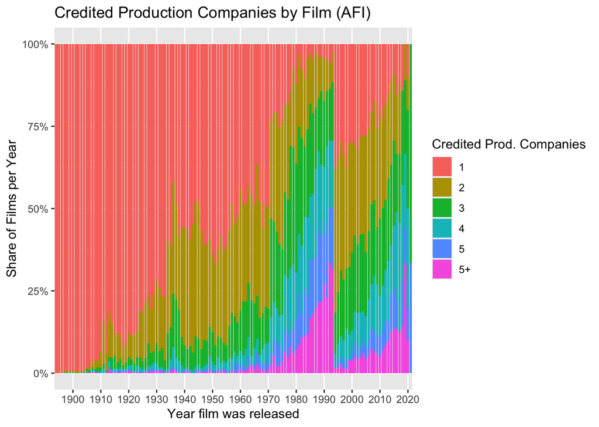

The graph for production companies follows a very similar pattern to the previous graph of credited producers. The database classifies all production companies as production companies, despite there being more than one type of production company. There are production companies as production companies, and there are production companies credited as in association with. The data does not carry this distinction which makes counting production companies less exact.

### Major releases only

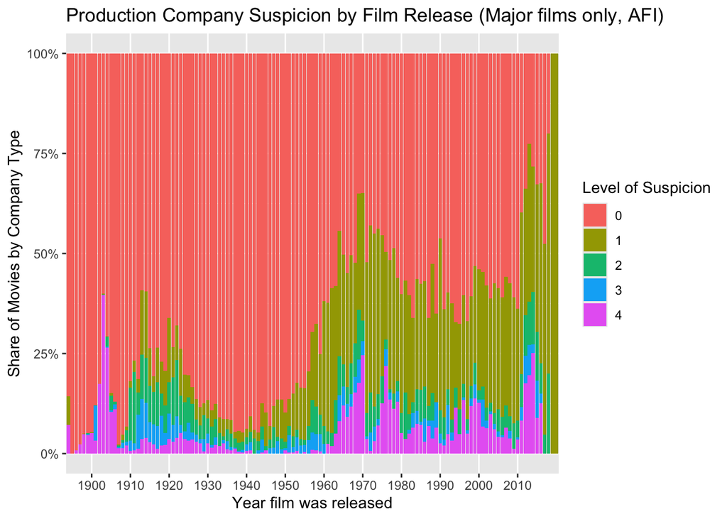

To consider a film to be major it must have been associated with at least one production company that has produced more than 50 films. The trend of increasing use of single use production still exists. This has to go with using the highest level of suspicion for production companies for films with multiple production companies. Most of the films are still produced by production companies that have produced more than one film, so they will be included in the data, then the highest level of suspicion will be used for the graphing.

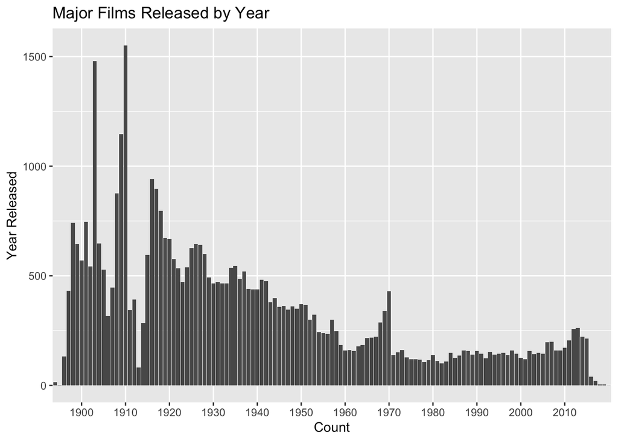

Mechanically there will be less major films for films released recently, as it will take time a for a new production company to produce 50 films.

### Conclusion

The collapsible corporation to take advantage of the tax break doesn’t seem to show in the data, we should see a large share of high level of type three production companies, as there are costs to creating a new corporation. To use a collapsible corporation only once is an expensive way to take an advantage of the tax break. Either this tax break was not used as much as we thought or the data is not capturing the tax break. Unfortunately this data is the best we had access to and we can’t make any further conclusions. A better constructed variable would be to incorporate film budgets. However this should not skew too much of the data as the target time frame is going to be the 80s, so there is a good amount of data before and after the target time frame. Given the limitations of data, we decided to move on from this project.